# W03-1: Reflection on Regression and Ch5 (Spending Our Data)

- Show All Code
- Hide All Code
- View Source

Author

Jake Evans

Published

July 8, 2026

# 1 Regression Fundamentals

**Linear Regression Basics**

> **Prompt:** *What is the goal of linear regression and why do we call it linear regression?*

Linear regression’s goal is to model the relationship between one or more *independent variables* (also called predictors), and a *continuous dependent variable* or outcome. It does this by fitting the **best straight line** through the data. The purpose of Linear Regression, is to understand how changes in the predictors are related to changes in the outcome, and using that relationship to make predictions for new observations.

Its called linear regression becasue the model assumes a linear relationship between the outcome and the predictors, in other words; the predicted outcome is written as a weighted combination of predictors:

$$\hat{y} = \beta_0 + \beta_1 x_1 + \beta_2 x_2 + \cdots + \beta_k x_k$$

**NoteNote**

In this equation, “Linear” refers to the parameters, represented by the beta values, rather than the predictors themselves.

**Residuals**

> **Prompt:** *What is a residual?*

A **residual** is the difference between the actual observed value and the value thats predicted by the regression model:

$$e_i = y_i - \hat{y}_i$$

In other words, residuals show how far off the model’s predictions are from the actual data. They represent the part of the outcome that the model can’t explain. Looking at residuals is important because they help us check whether the model’s assumptions are being met.

**Ordinary Least Squares Algorithm**

> **Prompt:** *When statistical software determines the best-fitting line, how does it do it? Elaborate on the algorithm.*

Statistical software uses **Ordinary Least Squares, or OLS**, to find the best fitting regression line. OLS works by minimizing the **Sum of Squared Residuals, also called SSR**:

$$\text{SSR} = \sum_{i=1}^{n} (y_i - \hat{y}_i)^2 = \sum_{i=1}^{n} e_i^2$$

**Squaring the residuals** serves two important purposes. First, it ensures that positive and negative errors do not cancel each other out. Secondly, it gives larger errors more weight, meaning the model is pushed to reduce big prediction mistakes.

Mathematically, OLS finds the best values for the regression coefficients by taking the partial derivatives of SSR with respect to each $\beta$ coefficient, setting them equal to zero, and solving the resulting equations. This produces the closed form solution known as the normal equation:

Squaring the residuals penalizes large errors more than small ones and ensures positive and negative errors do not cancel. Taking the partial derivatives of SSR with respect to each $\beta$ coefficient, setting them to zero, and solving yields closed-form **normal equations**:

$$\hat{\boldsymbol{\beta}} = (\mathbf{X}^\top \mathbf{X})^{-1} \mathbf{X}^\top \mathbf{y}$$

In practice, statistical software usually will use more stable computational methods, such as QR decomposition, instead of directly inverting $\mathbf{X}^\top \mathbf{X}$. However, the main idea remains the same: OLS chooses the line that minimizes the total squared vertical distance between the observes values and the fitted regression line.

# 2 R-Squared

**Definition**

> **Prompt:** What is R-Squared?

**R-squared** ($R^2$), also known as the *coefficient of determination*, shows how much of the variation in the outcome variable is explained by the regression model and itsvalues range from 0 to 1.

**NoteNote**

A value of 1 means that the model explains all of the variations in the outcome, while a value of 0 means that the model doesn’t explain any of it.

**Formula**

> **Prompt:** How do you calculate R-squared?

$$R^2 = 1 - \frac{\text{SS}_{\text{res}}}{\text{SS}_{\text{tot}}}$$

**Where:**

$\text{SS}_{\text{tot}} = \sum_{i=1}^{n}(y_i - \bar{y})^2$

This represents the total variation in the observed outcome values around the mean.

$\text{SS}_{\text{res}} = \sum_{i=1}^{n}(y_i - \hat{y}_i)^2$

This represents the unexplained variation, or the variation between the observed values and the values predicted by the regression model.

**In simple terms:** R-Squared compares how much error remains after fitting the regression model to the total amount of variation in the data. A higher R-Squared value means the model explains more of the variation in the outcome variable.

**Variation Components**

> **Prompt:** What is the variation around the mean? What is the variation around the regression line? What is variation around the mean minus variation around the line?

| Quantity | Formula | Meaning |
| --- | --- | --- |
| $\text{SS}_{\text{tot}}$ *Variation around the mean* | $\sum(y_i - \bar{y})^2$ | This is the total amount of variation in the outcome variable when the mean is used as the prediction for every observation. |
| $\text{SS}_{\text{res}}$ *Variation around the line* | $\sum(y_i - \hat{y}_i)^2$ | This is the amount of variation that remains unexplained after fitting the regression model. |
| $\text{SS}_{\text{reg}}$ *Difference* | $\text{SS}_{\text{tot}} - \text{SS}_{\text{res}}$ | This is the amount of variation explained by the regression model |

**In simple terms:** $\text{SS}{\text{tot}}$ shows how much the outcome values vary around the mean, while $\text{SS}{\text{res}}$ shows how much variation is left after using the regression line. The difference, $\text{SS}_{\text{reg}}$, how much uncertainty about the $y$ the model reduces compared to simply predicting the mean for everyone.

**Relationship Between R and R-Squared**

> **Prompt:** What is the relationship between R and R-Squared?

In **simple** linear regression, where there is only one predictor, $R^2$ is equal to the square of Pearson’s correlation coefficient, $r$:

$$R^2 = r^2$$

This also means $r = \pm\sqrt{R^2}$, with the sign depending on whether the slope is positive or negative. In **multiple** regression, $R^2$ still represents the squared correlation between the observed values and the fitted values from the model. However, it is no longer based on one simple two variable correlation. Instead, it reflects the overall linear relationship between the outcome variable and all predictors working together (while keeping them constant).

# 3 Implementing Linear Regression in R

**The t-Test in Regression Output**

> **Prompt:** What does the t-test do in the output? Answer using the null hypothesis.

In **regression output**, the t-test is used to determine whether each predictor has a statistically significant relationship with the outcome variable. For each coefficient, the **null hypothesis** is $H_0: \beta_j = 0$. This means the predictor has no linear effect on $y$, holding all other predictors constant.

The **alternative hypothesis** is $H_a: \beta_j \neq 0$, which means the predictor does have a linear relationship with the outcome.

The t-statistic is calculated as $t = \frac{\hat{\beta}_j}{\text{SE}(\hat{\beta}_j)}$.

If the p-value is below the chosen significance level, such as 0.05, we reject the null hypothesis. This means there is enough evidence to conclude that the predictor has a statistically significant linear relationship with the outcome variable.

**The F-Test in Regression Output**

> **Prompt:** What does the F-test do in the output? Answer using the null hypothesis.

In regression output, the **F-test** evaluates whether the regression model as a whole is statistically significant. The null hypothesis states that all slope coefficient are equal to zero: $H_0: \beta_1 = \beta_2 = \cdots = \beta_k = 0$. This means that none of the predictors explain variations in $y$.

The alternative hypothesis is $H_a: \text{At least one } \beta_j \neq 0$. This means that at least one predictor has a statistically significant relationship with the outcome variable.

The F-statistic is calculated as $F = \frac{\text{MS}_{\text{reg}}}{\text{MS}_{\text{res}}} = \frac{\text{SS}_{\text{reg}} / k}{\text{SS}_{\text{res}} / (n - k - 1)}$.

If the F-test is statistically significant, we reject the null hypothesis and conclude that the model explains more variation in the outcome than we would expect by chance. However, the F-test only tells us that the model is significant overall; it does not identify which specific predictors are responsible.

**Interpreting a Specific Result**

> **Prompt:** Suppose you ran a simple regression with one independent variable. The slope has a t-value of 1.97 with a p-value of 0.048.

**Statistical Significance**

> **Prompt:** What is your conclusion about the statistical significance of the independent variable?

Since $t = 1.97$ and $p = 0.048$, which is less than the 0.05 significance level, we reject the null hypothesis; $H_0: \beta_1 = 0$. This means there is enough statistical evidence to conclude that the independent variables have a significant linear relationship with the outcome variable.

**F-Statistic**

> **Prompt:** What would be the F-statistic? (Note: this may not have been taught in the video. In that case, you may refer to your old Stat book or search online)

In simple linear regression with one independent variable, the F-statistic is equal to the t-statistic squared. Since the t-value is $1.97$, the F-statistic is calculated as $F = t^2 = (1.97)^2 \approx 3.88$.

Therefore, the F-statistic would be approximately $3.88$.

**Overall Model Significance**

> **Prompt:** What would be your conclusion about the overall model’s significance based on the F-statistic? (Note: this may not have been taught in the video. In that case, you may refer to your old Stat book or search online)

Since $F \approx 3.88$ and $p = 0.048$, which is less than the 0.05 significance level, we reject the null hypothesis and conclude tha the overall regression model is statistically significant.

In simple linear regression, the F-test for the overall model and the t-test for the single independent variable are mathematically equivalent. This means they test the same basic hypothesis: whether the independent variable has a statistically significant linear relationship with the outcome variable. Because the p-value is below 0.05, the model as a whole is significant at a 5% level.

# 4 Multiple Regression

**Extension of Simple Regression**

> **Prompt:** How is multiple regression an extension of simple linear regression? Explain what changes when we move from one independent variable to two or more independent variables.

Simple linear regression models an outcome using one independent variable. The basic form is:
$$\hat{y} = \beta_0 + \beta_1 x_1$$

Multiple regression extends this idea by allowing the model to include two or more independent variables. The model becomes:
$$\hat{y} = \beta_0 + \beta_1 x_1 + \beta_2 x_2 + \cdots + \beta_k x_k$$

The main idea behind OLS staying the same, in both simple and multiple regression, the goal is to minimize the sum of squared residuals, or the total squared difference between the observed values and the predicted values. What changes i the interpretation of the coefficients. In simple regression, the slow shows the relationship between one predictor and the outcome. In multiple regression, each coefficient represents the effect of one predictor while holding all other predictors constant.

When we move from one independent variable to multiple independent variables, the coefficients will become partial slopes. Each $\hat{\beta}_j$ estimates the isolated effect of $x_j$ after controlling for the other variables in the model. Another important change is that $R^2$ can only increase or stay the same when more predictors are added, even if those predictors do not meaningfully improve the model. Because of this, adjusted $R^2$ or formal model comparison tests are often better for deciding whether additional predictors are even useful.

Multiple regression also requires more careful interpretations because predictors can be correlated with each other. The issue, called multicollinearity, can inflate standard errors and make individual coefficients estimates less stable. Overall, multiple regression is an extension of simple regression because it uses the same basic logic, but allows us to examine how several predictors work together to explain variations in the outcome.

**Why Adjusted R-Squared?**

> **Prompt:** Why is adjusted R-Squared often preferred over regular R-Squared in multiple regression? What is it trying to protect us from? Explain what the adjusted R-squared is trying to protect us from.

Adjusted $R^2$ is often preferred over regular $R^2$ in multiple regression because it accounts for the number of predictors in the model. Regular $R^2$ can only increase or stay the same when new independent variables are added, even if those variables don’t actually improve the model. This can make the model look better simply due to more predictors being added.

Adjusted $R^2$ uses the formula $\overline{R}^2 = 1 - \frac{(1 - R^2)(n - 1)}{n - k - 1}$, where $n$ is the sample size and $k$ is the number of predictors.

The purpose of adjusted $R^2$ is to protect us from **overfitting**. In other words, it helps prevent the mistake of thinking a model is better just because it includes more variables. If a new predictor does not improve the model enough to justify its additional complexity, adjusted $R^2$ can decrease. This makes it a more honest measure of model quality in multiple regression.

**Higher R-Squared Is Not Automatically Better**

> **Prompt:** Why is it not enough to say, “The multiple regression model has a higher R-Squared, so it is automatically better”? Explain what else we need to consider.

It is not enough to say that a multiple regression model is automatically better just because it has a higher $R^2$. Regular $R^2$ can increase simply because more predictors were added to the model, even if those predictors are not actually useful. This means a higher $R^2$ does not always mean the model is better at explaining the outcome in a meaningful way.

To judge whether the model is actually better, we need to consider several other factors. **Adjusted** $R^2$ is more important because it accounts for the number of predictors and can decrease if added variables do not improve the model enough. A **Model Comparison F-test** can also help determine whether the increase in explained variation is statistically significant. We should also think about **parsimony**, meaning that a simpler model is often better if it explains the data nearly as well as a more complex version.

In addition, we need to consider **practical significance**. Even if $R^2$ increases, the improvement may be too small to matter in a real world context. Finally, adding too many predictors can increase the risk of **overfitting,** where the model fits the sample data closely but performs poorly on new data. For these reasons, a higher $R^2$ should be considered alongside adjusted $R^2$, statistically significance, model simplicity, practical usefulness, and the risk of overfitting.

**Tail Length and the Model Comparison F-Test**

> **Prompt:** What does it mean if adding tail length increases R² but the model comparison F-test is not statistically significant?

If adding tail length increases $R^2$ but the model comparison F-test is not statistically significant, it means **the increase in explained variation is not strong enough to justify the additional length to the model**. In other words the model may look slightly $R^2$ increased, but the improvement is small enough that it could be just chance.

The null hypothesis for the model comparison F-test is $H_0: \text{The additional predictor(s) do not improve the model beyond chance}$.

If the test is not statistically significant we fail to reject the null hypothesis. This means there is not enough evidence to conclude that tail length menaingfully imrpoves the model. Because of this we would usually not keep tail length in the model. The increase in $R^2$ is likely due to random noise rather than any real improvement the adjusted $R^2$ would likely stay the same or possibly decrease.

**Significant t-Tests vs. Non-Significant F-Test**

> **Prompt:** Is it possible to observe significant t-tests for some predictors but a non-significant overall F-test?

Yest it is possible but it is uncommon. The reason is that the t-test and the overall F-test are testing different null hypothesis.

**A t-test looks at one predictor at a time and for each predictor**, the null hypothesis is $H_0: \beta_j = 0$. This means that the specific predictor has no statistically significant relationship with the outcome, while holding the other predictors constant.

**The overall F-test looks at the regression model as a whole**. Its null hypothesis is $H_0: \beta_1 = \beta_2 = \cdots = \beta_k = 0$. This means that none of the predictors, taken together, explain a statistically significant amount of variation in the outcome.

In practice, if one or more predictors have clearly significant t-tests, the overall F-test will usually also be significant. However, in borderline cases, especially with small samples, many predictors, or unstable estimates, it is possible for an individual t-test to appear significant while the overall F-test is not. This is why **both tests should be interpreted simultaneously** rather than relying on only one part of the regression output.

**Significant F-Test Does Not Guarantee All Predictors Are Important**

> **Prompt:** If a multiple regression model has a statistically significant F-test, does that mean every independent variable in the model is important?

No. A statistically significant F-test does not mean that every independent variable in the model is important. The F-test only tells us that the model as a whole is statistically significant, meaning **at least one predictor** has a relationship with the outcome variable.

A model could be significant overall because one strong predictor is explaining most of the variation, while the other predictors add little or nothing. To determine which specific predictors are important, we need to look at the individual t-tests for each coefficient. These t-tests will show whether each independent variable has a statistically significant relationship with the outcome (while holding the other predictors constant).

# 5 Running Regression in R

**Why Plot Before Fitting?**

> **Prompt:** Before fitting a regression model, why is it useful to plot the variables?

Before fitting a regression model, it is useful to plot the variables because a graph can reveal patterns or problems that may not be obvious from the numbers alone. A **scatterplot** can show whether the relationship looks linear or whether there is a curved pattern, which would suggest that a simple linear model may not be appropriate.

Plotting can also help identify **outliers**, which are extreme observations that may have a strong influence on the regression line. It can reveal **heteroscedasticity**, where the spread of the points changes across the range of the predictor, often appearing as a fan-shaped pattern. In addition, a plot may show **clusters or subgroups** in the data, which could suggest that a more complex model is needed.

Overall, plotting the variables first helps us avoid fitting a model blindly. It gives us a chance to check whether a linear regression model makes sense before drawing conclusions from the results.

**Simple vs. Multiple Regression: The Mouse Example**

> **Prompt:** Explain the difference between simple regression and multiple regression using the mouse example.

In the mouse example, **simple regression** uses one independent variable to predict the outcome. For example, body weight can be used to predict heart weight with the model $\widehat{\text{heart weight}} = \beta_0 + \beta_1 \times \text{body weight}$. In this case, there is one predictor and one slope, so the model is only looking at the relationship between body weight and heart weight.

**Multiple regression** extends this by adding two or more independent variables to the model. For example, if we add tail length, the model becomes $\widehat{\text{heart weight}} = \beta_0 + \beta_1 \times \text{body weight} + \beta_2 \times \text{tail length}$. Now the model is looking at both body weight and tail length together.

The main difference is how the coefficients are interpreted. In simple regression, the slope for body weight shows the overall relationship between body weight and heart weight. In multiple regression, each coefficient shows the effect of one predictor while holding the other predictor constant. This means the tail length coefficient tells us whether tail length explains additional variation in heart weight beyond what body weight already explains. If tail length does not add meaningful explanatory power, then including it only makes the model more complex without improving the prediction.

**Adjusted R-Squared in Model Evaluation**

> **Prompt:** Why should adjusted R-Squared be considered when evaluating a multiple regression model?

Adjusted $R^2$ should be considered when evaluating a multiple regression model because regular $R^2$ can be misleading. When we add more predictors to a model, regular $R^2$ will usually increase or stay the same, even if the new predictors are not actually useful. Adjusted $R^2$ helps correct for this by accounting for the number of predictors in the model. It penalizes unnecessary variables and only increases when a new predictor improves the model enough to justify the added complexity. This makes adjusted $R^2$ a better tool for comparing models with different numbers of predictors because it helps show whether the model is genuinely improving or simply becoming more complicated.

**Implication of a Non-Significant Tail Length**

> **Prompt:** If adding tail length does not significantly improve the model, what does that imply for data collection and model selection?

If adding tail length does not significantly improve the model, it suggests that tail length **does not provide meaningful predictive information** about heart weight beyond what body weight already explains. In other words, once body weight is already included in the model, tail length does not add enough value to justify keeping it.

For **data collection**, this means measuring tail length may not be necessary in the future because it adds extra work without improving prediction. Dropping it could save time and resources.

With **model selection**, the simpler model using only body weight would be preferred. This follows the principle of parsimony, or Occam’s Razor, which says that when two models perform similarly, the simpler model is usually better. A simpler model is also often easier to interpret and may generalize better to new data.

# 6 Regression Assumptions

> **Broad scenario:** A company studies whether advertising spending increases sales. A simple model might show a positive $\hat{\beta}_1$, but what if the company spends more during peak seasons, holidays, or in high-demand markets?

**Assumption at Issue: Independence / Omitted Variable Bias**

> **Prompt:** Suppose a company studies whether **advertising spending increases sales**. A simple model might show:

$$\text{Sales} = b_0 + b_1(\text{Advertising}) + \text{error}$$

> If $b_1$ is positive, we might conclude that advertising increases sales. But what if the company spends more on advertising during peak seasons, holidays, or in markets where demand is already high? Then the model may be conflating the effect of advertising with that of **seasonality, market demand, promotions, or brand strength**. What assumption is most likely an issue here?

The main issue is **omitted variable bias**, which is related to the independence or exogeneity assumption. In this example, advertising spending may be connected to other factors that also affect sales (such as seasonality, market demand, promotions, or brand strength). If those factors are left out of the model, the error term may capture their effects.

Because those omitted factors are likely related to advertising spending, the model may incorrectly attribute their impact to advertising. In other words, the coefficient on advertising may be biased because advertising is not being isolated from other influences on sales. Formally, this means the **error term is not independent of the predictor**, or $E[e_i \mid x_i] \neq 0$.

To better estimate the true effect of advertising, the model should include control variables for seasonality, market demand, promotions, and other factors that could also influence sales.

**Remaining Assumptions**

> **Prompt:**For the rest of the assumptions, provide a case where each of the rest of the assumptions can be an issue, and elaborate on your point. Still use the same scenario above—advertising’s effect on sales—as a broad basis for your response.

### 6.0.1 Linearity

One assumption of linear regression is that the **relationship between advertising spending and sales is linear**. However, this may not always be true. In many cases, advertising has diminishing returns, meaning that increasing ad spending does not always lead to an equal increase in sales. For example, the first $10,000 spent on advertising may generate a strong increase in sales, but doubling the budget may not double sales. If the true relationship is curved, a simple linear model may underpredict or overpredict sales at different spending levels. A residual plot could reveal this issue by showing a curved pattern.

### 6.0.2 Constant Variance (Homoscedasticity)

Another assumption is that **the errors have constant variance across all levels of advertising spending**. This could be a problem if larger markets with higher advertising budgets also have more unpredictable sales outcomes. For example, sales in a large market may vary much more than sales in a smaller market, even if both are included in the same model. This would create heteroscedasticity, where the residuals spread out more as advertising spending increases. While this does not necessarily bias the coefficient estimates, it can make the standard errors, p-values, and confidence intervals unreliable.

### 6.0.3 Normality of Errors

The model also assumes that **the residuals are approximately normally distributed**. In the advertising and sales example, this could be an issue if a few campaigns produce extremely large sales spikes. For instance, a holiday campaign or viral promotion could create unusually high sales compared to most other observations (4th of July for example). This can make the residuals skewed right instead of normally distributed. Non normal errors are especially concerning in smaller samples because they can affect the accuracy of p-values and confidence intervals.

### 6.0.4 No Perfect Multicollinearity

Regression also assumes that **the predictors are not perfectly correlated with each other**. In an advertising model, this could become a problem if the company always increases TV, digital, and social media advertising at the same time. If these advertising channels move together too closely, the model may struggle to separate the individual effect of each channel on sales. This can lead to inflated standard errors and unstable coefficient estimates.

### 6.0.5 No Influential Outliers

The final assumption is that **no single observation has too much influence on the regression results**. In this scenario, an influential outlier could be a single viral advertising campaign that produces unusually high sales with a modest budget. It could also be a crisis or supply shortage that causes sales to drop even though advertising spending was high. These observations can pull the regression line in one direction and distort the estimated relationship between advertising and sales.

# 7 Section 9 Exercises

**Exercise 1. Broom Practice**

> **Prompt:** Using the `customer_data` dataset (before splitting), fit a linear regression predicting `monthly_spend` from `tenure`, `num_products`, and `region`. Use `tidy()`, `glance()`, and `augment()` + ggplot2.

### 7.0.1 Linear Regression via lm()

> **Prompt:** Fit a linear regression predicting monthly_spend from tenure, num_products, and region

```r
spend_fit <- lm(monthly_spend ~ tenure + num_products + region,
                data = customer_data)
```

### 7.0.2 Coefficients via `tidy()`

> **Prompt:** Use tidy() to extract coefficients. Which predictors are significant at the 0.05 level?

```r
tidy(spend_fit) |>
  mutate(significant = p.value < 0.05)
```

| term | estimate | std.error | statistic | p.value | significant |
| --- | --- | --- | --- | --- | --- |
| (Intercept) | 51.6858164 | 2.17243733 | 23.7916259 | 2.162170e-99 | TRUE |
| tenure | 2.4544334 | 0.03692986 | 66.4620268 | 0.000000e+00 | TRUE |
| num_products | 9.9593289 | 0.46307446 | 21.5069709 | 1.512271e-84 | TRUE |
| regionNorth | 0.8852900 | 1.80836588 | 0.4895525 | 6.245586e-01 | FALSE |
| regionSouth | -1.8410306 | 1.82935234 | -1.0063838 | 3.144759e-01 | FALSE |
| regionWest | -0.8637471 | 1.82965603 | -0.4720817 | 6.369721e-01 | FALSE |

**Interpretation:** Predictors with $p < 0.05$ are considered statistically significant at the 5% level. Based on how the dataset was generated, tenure and num_products are expected to be significant positive predictors. This means customers with longer tenure or more products are likely to have higher monthly spending.

### 7.0.3 Model Fit via `glance()`

> **Prompt:** Use glance() to check R2. Is the model a good fit?

```r
glance(spend_fit)
```

| r.squared | adj.r.squared | sigma | statistic | p.value | df | logLik | AIC | BIC | deviance | df.residual | nobs |
| --- | --- | --- | --- | --- | --- | --- | --- | --- | --- | --- | --- |
| 0.8310624 | 0.8302126 | 20.38635 | 977.9657 | 0 | 5 | -4430.795 | 8875.59 | 8909.944 | 413109.4 | 994 | 1000 |

**Interpretation:** An$R^2$ value close to what we would expect from the data generating process suggests that the model fits the data well. Since tenure and num_products explain most of the signal in the dataset, a strong $R^2$ indicates that the **model is capturing the main drivers of monthly spending**. The F-test p-value being well below 0.05 also confirms that the **overall regression model is statistically significant**!

### 7.0.4 Residual Plot via `augment()`

> **Prompt:** Use augment() and ggplot2 to create a residual plot. Do you see any patterns?

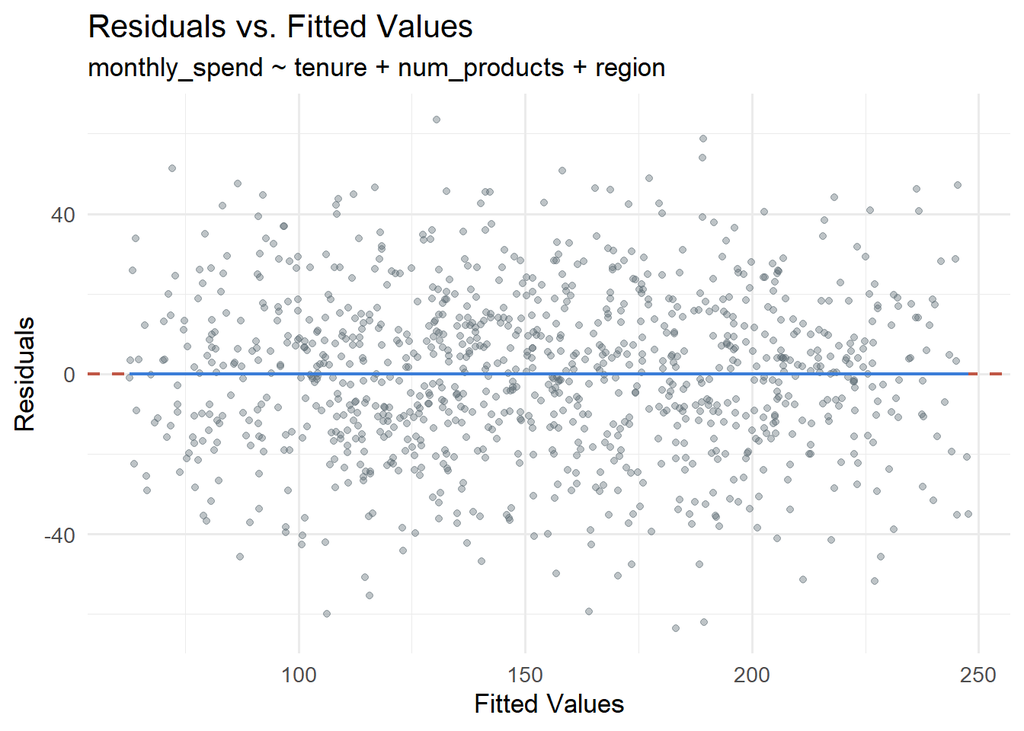

Residuals vs. Fitted Values — ideally scattered randomly around zero with no pattern.

```r
augment(spend_fit) |>
  ggplot(aes(x = .fitted, y = .resid)) +
  geom_point(alpha = 0.4, color = "#5C6B73") +
  geom_hline(yintercept = 0, linetype = "dashed", color = "#C05746", linewidth = 0.8) +
  geom_smooth(se = FALSE, color = "#3B7DD8", linewidth = 0.8) +
  labs(
    title = "Residuals vs. Fitted Values",
    subtitle = "monthly_spend ~ tenure + num_products + region",
    x = "Fitted Values",
    y = "Residuals"
  ) +
  theme_minimal(base_size = 13)
```

**Interpretation:** If the points are randomly scattered around zero without a clear curve or fan-shaped pattern, then the linearity and homoscedasticity assumptions appear to besatisfied. A smooth trend line that stays close to zero across the plot would further support this conclusion.

**Exercise 2. Data Splitting**

> **Prompt:**Create a 70/30 stratified split on `churn`. Verify churn rate similarity. Check `last_login_days` distribution.

### 7.0.5 Create the Split

> **Prompt:** Create a 70/30 stratified split on churn

```r
set.seed(123)
churn_split <- initial_split(customer_data, prop = 0.70, strata = churn)
churn_train <- training(churn_split)
churn_test  <- testing(churn_split)

cat("Training rows:", nrow(churn_train), "\n")
```

```
Training rows: 699
```

```r
cat("Testing rows: ", nrow(churn_test),  "\n")
```

```
Testing rows:  301
```

### 7.0.6 Verify Churn Rate

> **Prompt:** Verify that the churn rate is similar in both sets

```r
bind_rows(
  churn_train |> count(churn) |> mutate(set = "Training", pct = n / sum(n)),
  churn_test  |> count(churn) |> mutate(set = "Testing",  pct = n / sum(n))
) |>
  select(set, churn, n, pct) |>
  arrange(set, churn)
```

| set | churn | n | pct |
| --- | --- | --- | --- |
| Testing | No | 90 | 0.2990033 |
| Testing | Yes | 211 | 0.7009967 |
| Training | No | 207 | 0.2961373 |
| Training | Yes | 492 | 0.7038627 |

**Interpretation:** **Interpretation:** Stratified splitting keeps the churn rate nearly the same in both the training and test sets. This helps prevent one set from being artificially easier or harder than the other, making the model evaluation more fair and reliable.

### 7.0.7 Last Login Days Distribution

> **Prompt:** Check whether the distribution of last_login_days looks similar in training and testing

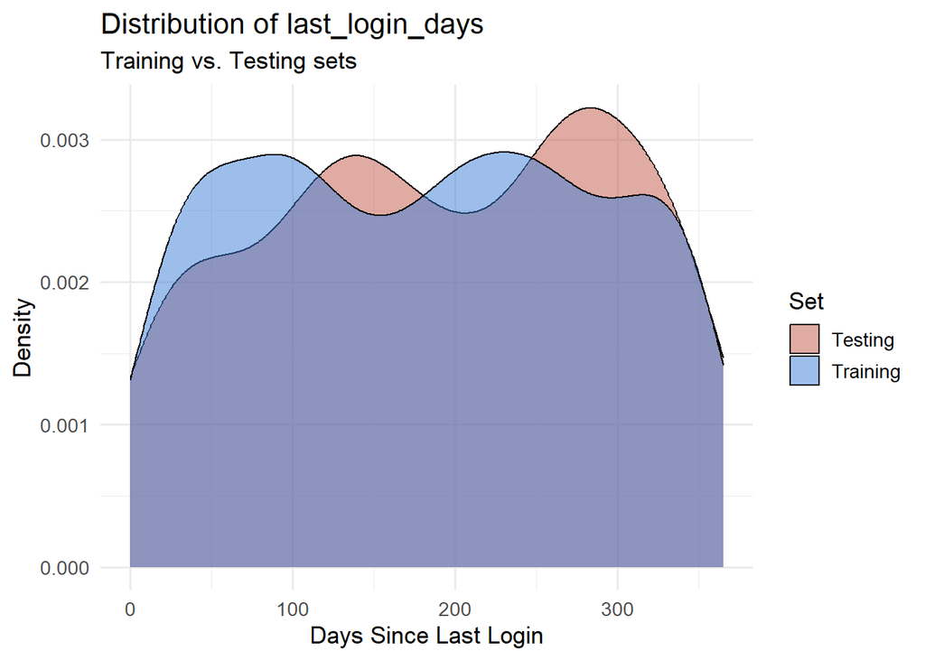

Overlapping density curves for last_login_days in training vs. test sets.

```r
bind_rows(
  churn_train |> mutate(set = "Training"),
  churn_test  |> mutate(set = "Testing")
) |>
  ggplot(aes(x = last_login_days, fill = set)) +
  geom_density(alpha = 0.5) +
  scale_fill_manual(values = c("Training" = "#3B7DD8", "Testing" = "#C05746")) +
  labs(
    title = "Distribution of last_login_days",
    subtitle = "Training vs. Testing sets",
    x = "Days Since Last Login",
    y = "Density",
    fill = "Set"
  ) +
  theme_minimal(base_size = 13)
```

**Interpretation:** The two curves should overlap closely, which would confirm that the split did not accidentally place more long dormant customers in one set than the other.

**Exercise 3. Critical Thinking**

### 7.0.8 Peeking at the Test Set

> **Prompt:**A colleague says: “I looked at the test set to understand the data better before modeling. I did not fit any models on it.” Is this a problem? Why or why not?

Yes, this is still a problem. Even if the colleague did not fit any models on the test set, looking at it before modeling can still influence their decisions. By examining the test set, they may learn about its distribution, outliers, or patterns; that information could unconsciously affect how they clean the data, engineer features, or choose models.

This is a form of data leakage because information from the test set is being used before the final evaluation. As a result, the model’s performance may look better than it would on truly uknown/unseen data which can create bias.

### 7.0.9 Stratified Splitting for Fraud Detection

> **Prompt:** You are building a fraud detection model. Only 0.1% of transactions are fraudulent. Why is stratified splitting especially important here?

Stratified splitting is especially important in this situation because fraud cases are extremely rare. If we used a regular random split, it would be possible for the training set or test set to end up with very few fraud cases, or possibly none at all.

This would create serious problems for the model. If the training set does not contain enough fraud examples, the model cannot properly learn the patterns associated with fraudulent transactions. If the test set does not contain enough fraud examples, the evaluation results may not accurately show how well the model performs on fraud detection.

Stratified splitting helps prevent this by keeping the fraud rate close to 0.1% in both the training and test sets. This makes the split more representative of the real-world data and allows the model to learn from genuine fraud cases while also being evaluated fairly.

### 7.0.10 High Training Accuracy, Low Test Accuracy

> **Prompt:** A model achieves 92% accuracy on the training set and 61% accuracy on the test set. What does this tell you? What would you do next?

The large gap of 31 percentage points is a clear sign of overfitting, which means the model is performing much better on the training data than on the test data, suggesting that it may have memorized patterns and noise in the training set instead of learning relationships that generalize well to new data.

To address this, the next steps would be to reduce model complexity, apply regularization methods such as L1 or L2 regularization, and use fewer features/simpler model setting.

# 8 Appendix

| Resource | Link |
| --- | --- |
| Published Report (GitHub Pages) | [https://jakevns.github.io/RStudio/](https://jakevns.github.io/RStudio/M02/Evans-Jake-W03-1-Reflection.html) |
| GitHub Repository | [https://github.com/jakevns/RStudio](https://github.com/jakevns/RStudio/tree/main/M02) |